# Exact Divide and Conquer Inference in Bayesian Linear Regression

Sudipto Banerjee

*Note:* To generate this HTML file, run `renderExactLMDivideAndConquer.sh` in the terminal from the `src/bigDataRegression/exactLM/run` directory. Alternatively find the source `Rmd` and `R` files in that same folder starting from the `BGC_2023` GitHub home.

```bash
# Navigate to the directory and run the compilation script
cd src/bigDataRegression/exactLM/run
./renderExactLMDivideAndConquer.sh
```

## Theory: Bayesian Updating with Independent Data

In a Bayesian framework, when dealing with independent data blocks conditionally on the parameters $\theta = \{\beta,\sigma^2\}$, we can sequentially update our posterior distribution for blocks $t=1,2,\ldots,T$.

By applying Bayes’ theorem, the joint probability can be factored as follows:
$$\begin{aligned}
p(\theta \mid y_1,\ldots,y_t) &\propto p(\theta, y_1,\ldots,
y_{t-1}, y_{t}) \\
&\propto p(\theta, y_1,\ldots, y_{t-1}) \times p(y_t \mid \theta,
y_1,\ldots, y_{t-1}) \\
&\propto p(\theta \mid y_1,\ldots, y_{t-1}) \times p(y_t\mid
\theta)\;.
\end{aligned}$$

Because the data is assumed to be independent given $\theta$, the term $p(y_t \mid \theta, y_1,\ldots, y_{t-1})$ simplifies directly to the likelihood of the current block, $p(y_t \mid \theta)$. Consequently, the posterior from the previous time step $t-1$ becomes the exact prior for the next time step $t$. This property allows us to “Divide & Conquer” by loading manageable blocks of data into memory one at a time.

## Model Setup: Bayesian Regression

To apply this to linear regression, we partition our full dataset into independent blocks denoted as $\{y_t, X_t\}$ for $t=1,2,\ldots,T$. Here, $y_t$ is an $n_t \times 1$ response vector, $X_t$ is an $n_t \times p$ design matrix, and the total number of observations is $n=\sum_{t=1}^T n_t$.

We assume block independence with a standard Gaussian likelihood and conjugate Normal-Inverse-Gamma priors:
$$\begin{aligned}
y_t \mid \beta, \sigma^2 &\overset{ind}{\sim} N(X_t\beta, \sigma^2
V_t) \\
\beta \mid \sigma^2 &\sim N(M_0m_0, \sigma^2M_0) \\
\sigma^2 &\sim IG(a_0, b_0)\;.
\end{aligned}$$

Letting $\theta = \{\beta,\sigma^2\}$, the full posterior $p(\theta \mid y)$ is proportional to the joint distribution:
$$p(\theta \mid y) \propto IG(\sigma^2 \mid a_0,b_0) \times N(\beta \mid
M_0 m_0, \sigma^2 M_0) \times \prod_{t=1}^{T} N(y_t \mid X_t\beta,
\sigma^2 V_{t})\;.$$

> **Note:** If every single data point is entirely independent, then $V_t = I_{n_t}$. If not, data collection and partitioning should be designed so that observations are independent across the specific blocks.

## Exact Posterior Updates

Because of conjugacy, the posterior distribution at time $t-1$ maintains the exact same Normal-Inverse-Gamma family form:
$$p(\theta \mid y_1,\ldots, y_{t-1}) = IG\left(\sigma^2 \mid a_{t-1},
b_{t-1}\right) \times N\left(\beta \mid M_{t-1}m_{t-1}, \sigma^2
M_{t-1}\right)$$

When the $t$-th block of data is processed, the posterior updates analytically to:
$$p(\theta \mid y_1,\ldots, y_{t}) = IG\left(\sigma^2 \mid a_{t},
b_{t}\right) \times N\left(\beta \mid M_{t}m_{t}, \sigma^2 M_{t}\right)$$

The sufficient statistics $a_t$, $b_t$, $m_t$, and $M_t$ are updated sequentially using the following algebraic rules:
$$\begin{aligned}
m_{t} &= m_{t-1} + X_t^{\top}V_t^{-1}y_t \\
M_t^{-1} &= M_{t-1}^{-1} + X_t^{\top}V_t^{-1}X_t \\
a_t &= a_{t-1} + \frac{n_t}{2} \\
b_t &= b_{t-1} + \frac{q_t}{2}
\end{aligned}$$
where the scale factor $q_t$ for the Inverse-Gamma distribution is defined as:
$$q_t = y_t^{\top}y_t + m_{t-1}^{\top}M_{t-1}m_{t-1} -
m_{t}^{\top}M_{t}m_{t}\;.$$

## Algorithmic Implementation

To implement this sequentially on Big Data, we rely on a computationally efficient loop. While we can use the direct matrix equations, utilizing Cholesky decompositions ensures greater numerical stability.

**Algorithm: Exact Posterior Sampling (using linear algebra optimizations)**

1. **Initialize Priors:** Set $m \gets m_0$, $M^{-1} \gets M_0^{-1}$, $a \gets a_0$, and $b \gets b_0$.
2. **Initialize Matrices:** Compute the Cholesky factor $L^{-1} \gets \text{cholesky}(M^{-1})$ and solve for $L = \text{trsolve}(L^{-1}, I_p)$.
3. **Divide and Conquer Loop:** For each block $t$ in $1$ to $T$:
   - $q \gets \|y_t\|^2 + \|Lm\|^2$
   - Update sufficient statistics: $m \gets m + X_t^{\top}V_t^{-1}y_t$ and $M^{-1} \gets M^{-1} + X_t^{\top}V_t^{-1}X_t$
   - Recompute Cholesky factors: $L^{-1} \gets \text{cholesky}(M^{-1})$ and $L = \text{trsolve}(L^{-1}, I_p)$
   - Finalize scalar updates: $q \gets q - \|Lm\|^2$
   - Update shape and scale: $b \gets b + q/2$ and $a \gets a + n_t/2$
4. **Posterior Sampling:** For $i$ in $1$ to $N$:
   - Draw variance: $\sigma^2_{(i)} \sim IG(a,b)$
   - Draw standard normal vector: $z \sim N(0, I_p)$
   - Compute coefficients: $\beta_{(i)} \gets L^{\top}Lm + \sigma_{(i)}L^{\top}z$
5. **Return:** $\left\{\beta_{(i)},\sigma^2_{(i)}\right\}_{i=1,\ldots,N}$

## Section 1: Partition the Data

First, we read the data, which includes the variables `Y`, `X1` through `X6`, `Lat`, and `Longi`. We partition the total 1369 rows into 10 blocks: the first 9 datasets will have exactly 130 rows, and the 10th dataset will contain the remaining 199 rows.

```r
# 1. Load Data
data <- read.table("../data/data.txt", header = TRUE)

# Prepare the Model Matrix and Response Vector
X_full <- as.matrix(cbind(Intercept = 1, data[, c("X1", "X2", "X3", "X4", "X5", "X6", "Lat", "Longi")]))
y_full <- as.numeric(data$Y)

# 2. Partition into Blocks using vectorized operations
T_blocks <- 10
block_size <- 130
total_n <- nrow(X_full)

# Create a grouping vector for splitting
group_indices <- c(
  rep(1:(T_blocks - 1), each = block_size),
  rep(T_blocks, total_n - (T_blocks - 1) * block_size)
)

# Split data into lists efficiently
X_list <- lapply(split(as.data.frame(X_full), group_indices), as.matrix)
y_list <- unname(split(y_full, group_indices))

cat("Successfully created", length(X_list), "data blocks.\n")
```

```
## Successfully created 10 data blocks.
```

```r
cat("Rows in block 1-9:", nrow(X_list[[1]]), "| Rows in block 10:", nrow(X_list[[10]]), "\n")
```

```
## Rows in block 1-9: 130 | Rows in block 10: 199
```

## Section 2: Sequential Bayesian Updating

Here we implement the block-sequential updating. The analytic expressions for the posterior at block t become the conjugate Normal-Gamma prior for block t+1. After T=10 blocks, we draw N=5000 exact samples from the final posterior distribution.

```r
# Setup Priors (Weakly Informative)
p <- ncol(X_full)
M0_inv <- matrix(0, nrow = p, ncol = p)
m0 <- rep(0, p)
a0 <- 0.01
b0 <- 0.01
N_samples <- 5000

# Run Divide and Conquer Sampler (T = 10)
set.seed(123)
res_T10 <- rawSamplerDivideAndConquer(
  X_list = X_list,
  y_list = y_list,
  M0_inv = M0_inv, m0 = m0, a0 = a0, b0 = b0,
  N = N_samples
)

# Summarize T=10
draws_T10 <- as.data.frame(res_T10$draws)
summary_T10 <- data.frame(
  Parameter = colnames(draws_T10),
  Mean_T10 = colMeans(draws_T10),
  SD_T10 = apply(draws_T10, 2, sd)
)
kable(summary_T10, digits = 4, caption = "Posterior Summaries (Divide and Conquer, T=10)")
```

Posterior Summaries (Divide and Conquer, T=10)

|  | Parameter | Mean_T10 | SD_T10 |
| --- | --- | --- | --- |
| Intercept | Intercept | -552.5349 | 89.0898 |
| X1 | X1 | 0.0610 | 0.0012 |
| X2 | X2 | -0.0018 | 0.0003 |
| X3 | X3 | -0.0492 | 0.0082 |
| X4 | X4 | -0.0691 | 0.0088 |
| X5 | X5 | 0.0287 | 0.0090 |
| X6 | X6 | 4.6980 | 0.9010 |
| Lat | Lat | -2.4022 | 0.3099 |
| Longi | Longi | -5.3960 | 0.8033 |
| sigma | sigma | 0.1509 | 0.0029 |
| sigma2 | sigma2 | 0.0228 | 0.0009 |
| tau | tau | 43.9338 | 1.6592 |

## Section 3: Comparisons

To demonstrate the exactness of the divide and conquer approach, we now process the dataset as a single block (T=1) and compare the samples. Because the updating scheme uses sufficient statistics, the theoretical posterior is mathematically identical.

```r
# Run Single Block Sampler (T = 1)
set.seed(123) # Use same seed to demonstrate distributional equivalence
res_T1 <- rawSamplerDivideAndConquer(
  X_list = list(X_full),
  y_list = list(y_full),
  M0_inv = M0_inv, m0 = m0, a0 = a0, b0 = b0,
  N = N_samples
)

draws_T1 <- as.data.frame(res_T1$draws)
summary_T1 <- data.frame(
  Parameter = colnames(draws_T1),
  Mean_T1 = colMeans(draws_T1),
  SD_T1 = apply(draws_T1, 2, sd)
)

# Merge summaries
comparison_df <- merge(summary_T1, summary_T10, by = "Parameter")
kable(comparison_df, digits = 4, caption = "Posterior Comparison: T=1 vs T=10")
```

Posterior Comparison: T=1 vs T=10

| Parameter | Mean_T1 | SD_T1 | Mean_T10 | SD_T10 |
| --- | --- | --- | --- | --- |
| Intercept | -552.5351 | 89.0898 | -552.5349 | 89.0898 |
| Lat | -2.4022 | 0.3099 | -2.4022 | 0.3099 |
| Longi | -5.3960 | 0.8033 | -5.3960 | 0.8033 |
| sigma | 0.1509 | 0.0029 | 0.1509 | 0.0029 |
| sigma2 | 0.0228 | 0.0009 | 0.0228 | 0.0009 |
| tau | 43.9338 | 1.6592 | 43.9338 | 1.6592 |
| X1 | 0.0610 | 0.0012 | 0.0610 | 0.0012 |
| X2 | -0.0018 | 0.0003 | -0.0018 | 0.0003 |
| X3 | -0.0492 | 0.0082 | -0.0492 | 0.0082 |
| X4 | -0.0691 | 0.0088 | -0.0691 | 0.0088 |
| X5 | 0.0287 | 0.0090 | 0.0287 | 0.0090 |
| X6 | 4.6980 | 0.9010 | 4.6980 | 0.9010 |

### Q-Q Plots for Distributional Validation

To visually confirm that the resulting distributions are practically indistinguishable, we plot the sorted posterior samples against one another. The 45-degree line represents perfect equality, and R-squared indicates the correlation.

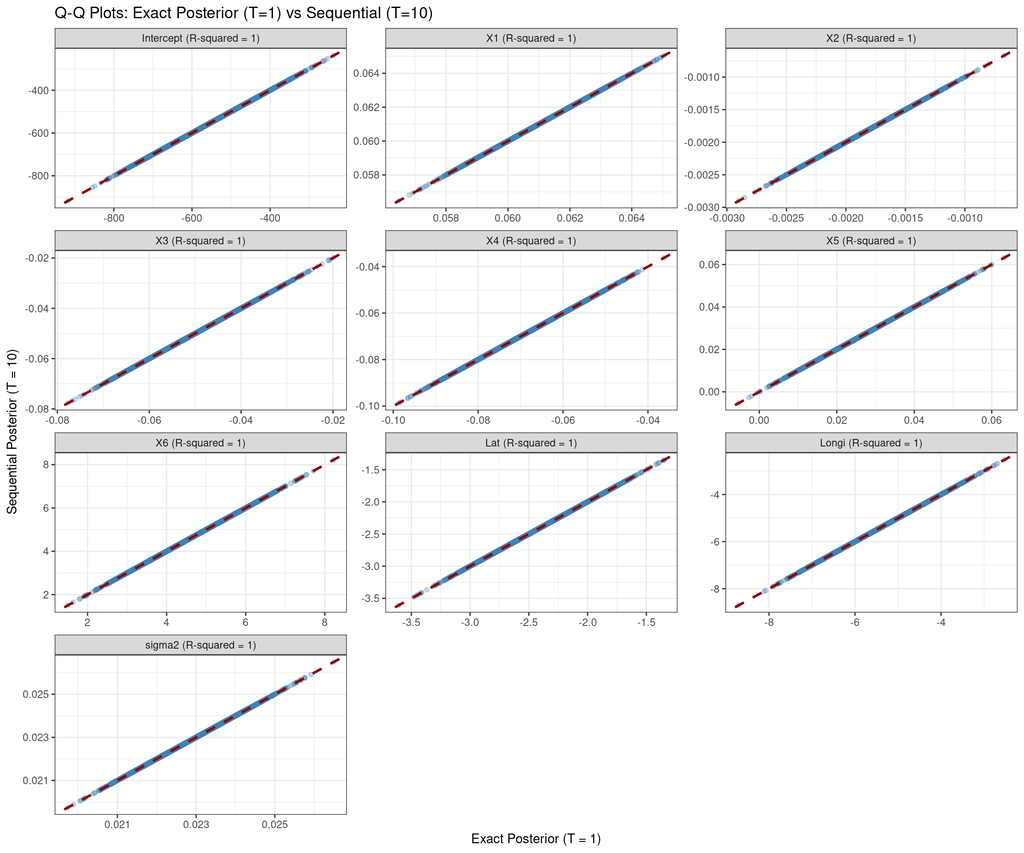

```r
params_to_plot <- c("Intercept", "X1", "X2", "X3", "X4", "X5", "X6", "Lat", "Longi", "sigma2")

# Vectorized alignment and R-squared calculation
plot_data_list <- lapply(params_to_plot, function(param) {
  q_T1 <- sort(draws_T1[[param]])
  q_T10 <- sort(draws_T10[[param]])
  r_squared <- cor(q_T1, q_T10)^2

  data.frame(
    Facet_Label = paste0(param, " (R-squared = ", round(r_squared, 6), ")"),
    Exact_T1 = q_T1,
    Sequential_T10 = q_T10
  )
})

df_plot_all <- do.call(rbind, plot_data_list)

# Convert Facet_Label to a factor to enforce the specific plotting order
df_plot_all$Facet_Label <- factor(df_plot_all$Facet_Label, levels = unique(df_plot_all$Facet_Label))

ggplot(df_plot_all, aes(x = Exact_T1, y = Sequential_T10)) +
  geom_point(alpha = 0.3, color = "steelblue") +
  geom_abline(slope = 1, intercept = 0, color = "darkred", linetype = "dashed", linewidth = 1) +
  facet_wrap(~ Facet_Label, scales = "free", ncol = 3) +
  labs(
    title = "Q-Q Plots: Exact Posterior (T=1) vs Sequential (T=10)",
    x = "Exact Posterior (T = 1)",
    y = "Sequential Posterior (T = 10)"
  ) +
  theme_bw()
```

## Section 4: Analysis with the Centered and Scaled X matrix

Centering and scaling the predictor matrix prior to Bayesian regression provides two substantial benefits. First, it standardizes the scale of all covariates (subtracting the mean and dividing by the standard deviation), ensuring that predictors with inherently larger magnitude scales do not disproportionately influence the matrix inversion or variance components. Second, centering alters the interpretation of the intercept; rather than representing the expected value of Y when all predictors equal zero, the intercept now intuitively represents the expected value of Y when all predictors are at their sample means.

```r
# Scale covariates (exclude intercept to prevent variance collapse)
covariates <- data[, c("X1", "X2", "X3", "X4", "X5", "X6", "Lat", "Longi")]
X_scaled <- as.matrix(cbind(Intercept = 1, scale(covariates)))

# Split the scaled data efficiently
X_list_scaled <- lapply(split(as.data.frame(X_scaled), group_indices), as.matrix)

# Run Divide and Conquer Sampler on Scaled Data (T = 10)
set.seed(123)
res_scaled_T10 <- rawSamplerDivideAndConquer(
  X_list = X_list_scaled,
  y_list = y_list,
  M0_inv = M0_inv, m0 = m0, a0 = a0, b0 = b0,
  N = N_samples
)

# Summarize Scaled T=10
draws_scaled_T10 <- as.data.frame(res_scaled_T10$draws)
summary_scaled_T10 <- data.frame(
  Parameter = colnames(draws_scaled_T10),
  Mean_Scaled_T10 = colMeans(draws_scaled_T10),
  SD_Scaled_T10 = apply(draws_scaled_T10, 2, sd)
)

# Run Single Block Sampler on Scaled Data (T = 1)
set.seed(123)
res_scaled_T1 <- rawSamplerDivideAndConquer(
  X_list = list(X_scaled),
  y_list = list(y_full),
  M0_inv = M0_inv, m0 = m0, a0 = a0, b0 = b0,
  N = N_samples
)

# Summarize Scaled T=1
draws_scaled_T1 <- as.data.frame(res_scaled_T1$draws)
summary_scaled_T1 <- data.frame(
  Parameter = colnames(draws_scaled_T1),
  Mean_Scaled_T1 = colMeans(draws_scaled_T1),
  SD_Scaled_T1 = apply(draws_scaled_T1, 2, sd)
)

# Merge summaries for the scaled comparison
comparison_scaled_df <- merge(summary_scaled_T1, summary_scaled_T10, by = "Parameter")
kable(comparison_scaled_df, digits = 4, caption = "Posterior Comparison (Scaled): T=1 vs T=10")
```

Posterior Comparison (Scaled): T=1 vs T=10

| Parameter | Mean_Scaled_T1 | SD_Scaled_T1 | Mean_Scaled_T10 | SD_Scaled_T10 |
| --- | --- | --- | --- | --- |
| Intercept | 11.6841 | 0.0041 | 11.6841 | 0.0041 |
| Lat | -0.0648 | 0.0084 | -0.0648 | 0.0084 |
| Longi | -0.1451 | 0.0216 | -0.1451 | 0.0216 |
| sigma | 0.1509 | 0.0029 | 0.1509 | 0.0029 |
| sigma2 | 0.0228 | 0.0009 | 0.0228 | 0.0009 |
| tau | 43.9338 | 1.6592 | 43.9338 | 1.6592 |
| X1 | 0.2964 | 0.0058 | 0.2964 | 0.0058 |
| X2 | -0.0386 | 0.0060 | -0.0386 | 0.0060 |
| X3 | -0.0347 | 0.0057 | -0.0347 | 0.0057 |
| X4 | -0.0328 | 0.0042 | -0.0328 | 0.0042 |
| X5 | 0.0128 | 0.0040 | 0.0128 | 0.0040 |
| X6 | 0.1110 | 0.0213 | 0.1110 | 0.0213 |

### Q-Q Plots for Scaled Distributional Validation

To ensure the exact divide and conquer approach holds true for our centered and scaled data, we plot the sorted posterior samples against each other, calculating the R-squared for the exactness of the match.

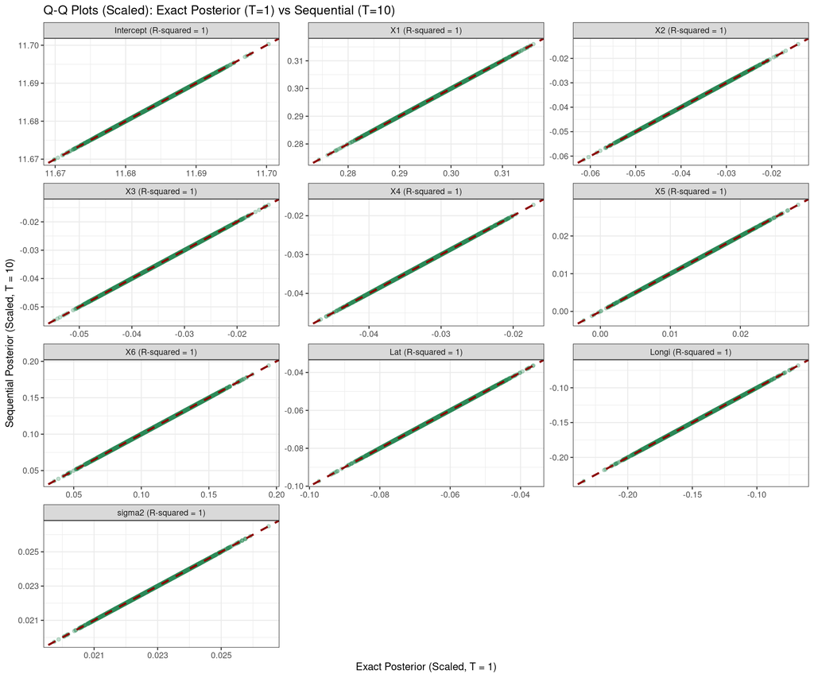

```r
# Vectorized alignment and R-squared calculation for scaled data
plot_data_list_scaled <- lapply(params_to_plot, function(param) {
  q_T1_scaled <- sort(draws_scaled_T1[[param]])
  q_T10_scaled <- sort(draws_scaled_T10[[param]])
  r_squared_scaled <- cor(q_T1_scaled, q_T10_scaled)^2

  data.frame(
    Facet_Label = paste0(param, " (R-squared = ", round(r_squared_scaled, 6), ")"),
    Exact_T1 = q_T1_scaled,
    Sequential_T10 = q_T10_scaled
  )
})

df_plot_all_scaled <- do.call(rbind, plot_data_list_scaled)

# Convert Facet_Label to a factor to enforce the specific plotting order
df_plot_all_scaled$Facet_Label <- factor(df_plot_all_scaled$Facet_Label, levels = unique(df_plot_all_scaled$Facet_Label))

ggplot(df_plot_all_scaled, aes(x = Exact_T1, y = Sequential_T10)) +
  geom_point(alpha = 0.3, color = "seagreen") +
  geom_abline(slope = 1, intercept = 0, color = "darkred", linetype = "dashed", linewidth = 1) +
  facet_wrap(~ Facet_Label, scales = "free", ncol = 3) +
  labs(
    title = "Q-Q Plots (Scaled): Exact Posterior (T=1) vs Sequential (T=10)",
    x = "Exact Posterior (Scaled, T = 1)",
    y = "Sequential Posterior (Scaled, T = 10)"
  ) +
  theme_bw()
```